# P4 - Red Wine Quality - Exploratory Data Analysis by S.Jaeger

# Multivariate Analysis

### Talk about some of the relationships you observed in this part of the investigation. Were there features that strengthened each other in terms of looking at your feature(s) of interest?

Plotting the density vs the fixed.acidity with color encoding by quality was quite interesting. Especially looking at the regression lines. We can compare regression line for excellent and very bad wines (the two extreme quality) and we can notice that they are almost parallel.  
This means that density seems to increases linearly with fixed.acidity for a given quality, and that the slope of the density over fixed.acidity is the same for those two extreme qualities.

### Were there any interesting or surprising interactions between features?

Those parallel regression lines are an interesting finding, which I can not explain with my low chemical skills, but this finding could be used for example to automatically cluster wines of unknown quality and to predict in advance how they would be rated.

We find the same type of relationship within the second plot of density vs pH, with decreasing regression lines. Again, regression line for excellent and very bad wines (the two extreme quality) are almost parallel. This result sounds logical as somehow, pH is inversely proportional to acidity. So this second graph does not bring really new insights but confirms our previous analysis.

### OPTIONAL: Did you create any models with your dataset? Discuss the strengths and limitations of your model.

Not really a model, but let us say a method based on regression lines to predict quality of wine given density & fixed.acidity. I guess this would be an over-simplified predictor as:  
- There are many other chemical properties I did not take into account into this model.  
- It seems to work well for excellent & very bad wines, with very segregated parallel lines, but those are the two categories were we have only very few samples, so it could be not relevant to infer a model from a so small samples. For the other qualities, we see lines intersecting at some point (where fixed.acidity & density are high, or otherwise put, where pH is low and density high). So we can guess that around this intersection point it would be quite hard to distinguish between other wines qualities.  
This would make such a model not accurate for some parts of the data (where pH is low and density high) and more relevant in other cases (pH high & density low) However the advantage of such model would be its simplicity and processing speed: keeping only the two regression lines for excellent and very bad qualities, compute the distance from a sample red wine from those lines (and keeping the minimal one) could indicate whether it is likely to be a good or bad wine.

# Final Plots and Summary

### Plot One

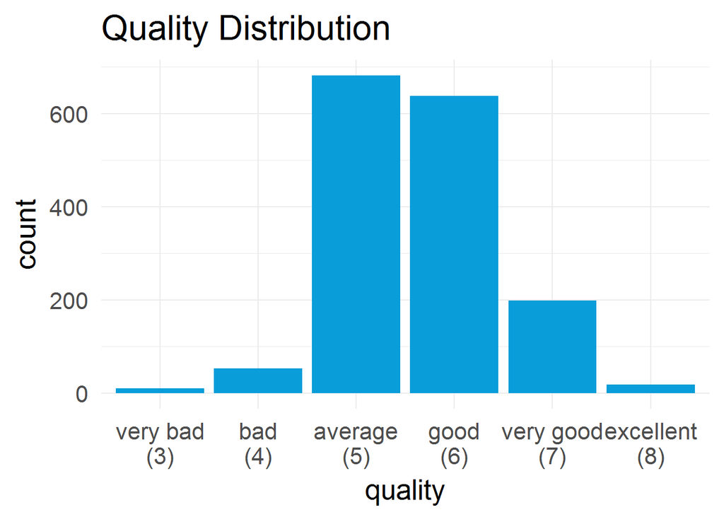

### Description One

I admit this one is basic but at the same time, it is the most useful to characterize the quality distribution wich is the main studied variable of this dataset. So, if I have to choose three plots, I would definitely choose this one first.